```python
# Graham Healy 2020
```

# Imports

```python
import numpy, scipy, matplotlib, mne, sklearn, pandas, os, os.path
import mne.io, pylab
import statsmodels
import statsmodels.tsa.stattools
import scipy.stats
import seaborn
import random
import collections
import datetime, time
import torchvision, torchvision.transforms, torchvision.models
import torch
import PIL
import scipy.spatial.distance
import scipy.stats
import shutil
import numpy.linalg

def mkdir(dir_path):
    if not os.path.exists(dir_path):
        os.makedirs(dir_path)
```

# Defs, Constants, Paths, ...

```python
SUB_ID = 1003

SHOW_DATA_DIST_PLOTS = False

IMAGE_NET_CLASSES_FILE = "/home/ham/projects/mart/imagenet_classes.txt"
BASE_PATH = "/home/ham/projects/mart/mart_data/{}/".format(SUB_ID)

DATA_OUTPUT_DIR = "/home/ham/projects/mart/OUTPUT/{}".format(SUB_ID)
#DATA_OUTPUT_DIR_TXT = "/home/ham/projects/mart/OUTPUT_txt/"
#DATA_OUTPUT_DIR_PANDAS = "/home/ham/projects/mart/OUTPUT_pandas/"
#DATA_OUTPUT_DIR_SECRETS = "/home/ham/projects/mart/OUTPUT_secrets/"

DATA_OUTPUT_DIR_TXT = os.path.join(DATA_OUTPUT_DIR, "RAW")
DATA_OUTPUT_DIR_PANDAS = os.path.join(DATA_OUTPUT_DIR, "PANDAS")
DATA_OUTPUT_DIR_SCREENSHOTS = os.path.join(DATA_OUTPUT_DIR, "SCREENSHOTS")
DATA_OUTPUT_DIR_AUTOGRAPHER = os.path.join(DATA_OUTPUT_DIR, "AUTOGRAPHER")

DATA_OUTPUT_DIR_SECRETS = os.path.join("/home/ham/projects/mart", "SECRET")

EOG_DATA_PATH = os.path.join(BASE_PATH, "{}.edf".format(SUB_ID) )
ACC_DATA_PATH = os.path.join(BASE_PATH, "razors_{}.txt".format(SUB_ID) )
HR_DATA_PATH = os.path.join(BASE_PATH, "heart_{}.txt".format(SUB_ID) )
PSYCHOPY_PATH = os.path.join(BASE_PATH, "psychopy_log_{}".format(SUB_ID) )
KHIEMS_PI_SYNCED_TIME_LOGGER_PATH = os.path.join(BASE_PATH, "mainpc_{}.txt".format(SUB_ID) )
AUTOGRAPHER_IMAGES_DIR = os.path.join(BASE_PATH, "ims/")

#LOGGERMAN_IMAGES_DIR =  "/home/ham/projects/mart/mart_data/loggerman_1005upwards/Screen_all/"
#LOGGERMAN_MOUSE_LOG =  "/home/ham/projects/mart/mart_data/loggerman_1005upwards/Mouse/0.txt"

LOGGERMAN_IMAGES_DIR =  "/home/ham/projects/mart/mart_data/loggerman/Screen_all/"
LOGGERMAN_MOUSE_LOG =  "/home/ham/projects/mart/mart_data/loggerman/Mouse/0.txt"

ACC_GRAVITY_CONST = 1
NUM_REPEATS_PER_EVENT = 3

# we maintain this with correspondin pc time from visual inspection of images
autographer_alignment = {1001: ('B00002683_21I6TX_20180515_071400E',1584112764.92), #
                         1002: ('B00003550_21I6TX_20180518_025644E',1584356541.46), # 1002 is 2020-03-16 11:02:21.46
                        1003: ('B00004462_21I6TX_20180717_054344E', 1589550578.86),
                        1004: ('B00005230_21I6TX_20180718_083424E', 1589647222.75),
                        1005: ('B00005906_21I6TX_20180722_131719E', 1590009814.53)}

with open(IMAGE_NET_CLASSES_FILE) as f:
  IMAGE_NET_CLASSES = [line.strip() for line in f.readlines()]

for name in IMAGE_NET_CLASSES:
    if IMAGE_NET_CLASSES.count(name) > 1:
        print(name)
```

```python
processed_sensor_data = {}
```

# Load timestamp files

- to align pc, laptop and pi

```
the PC is 2.1511526107788086 seconds ahead of the pi
```

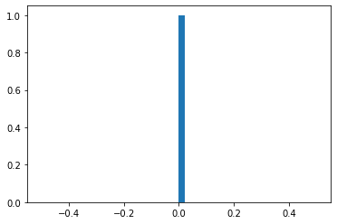

```python
with open( os.path.join(BASE_PATH, KHIEMS_PI_SYNCED_TIME_LOGGER_PATH), 'r' ) as fin:
    pc_pi_log = fin.readlines()
pc_pi_log = [x.strip().split() for x in pc_pi_log if 'raspi' in x ]
pc_times = [float(x[0]) for x in pc_pi_log]
pi_times = [float(x[2]) for x in pc_pi_log]
pc_pi_diffs = [x-y for x,y in zip(pc_times, pi_times)]

# and assume the diff = average
PC_PI_DIFF = numpy.average(pc_pi_diffs)

# visual check the variance isin't large
pylab.hist(numpy.array(pc_pi_diffs) - PC_PI_DIFF, bins=50) # take away average distance to see in sensible scale

print('the PC is {} seconds ahead of the pi'.format(PC_PI_DIFF))

PI_TO_PI_TIME = lambda x: x+PC_PI_DIFF
PC_TO_PI_TIME = lambda x: x-PC_PI_DIFF
```

```
the PC is 2.331995872062022 seconds ahead of the laptop
```

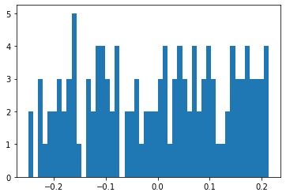

```python
with open( os.path.join(BASE_PATH, KHIEMS_PI_SYNCED_TIME_LOGGER_PATH), 'r' ) as fin:
    pc_pi_log = fin.readlines()

# use first activity to align
pc_times = [ float(x.split(' ')[0]) for x in pc_pi_log if "laptop" in x or 'Laptop' in x]
laptop_times = [ float(x.split(' ')[2]) for x in pc_pi_log if "laptop" in x or 'Laptop' in x]

pc_laptop_diffs = [x-y for x,y in zip(pc_times, laptop_times)]

# and assume the diff = average
PC_LAPTOP_DIFF = numpy.average(pc_laptop_diffs)

# visual check the variance isin't large
pylab.hist(numpy.array(pc_laptop_diffs) - PC_LAPTOP_DIFF, bins=50) # take away average distance to see in sensible scale

print('the PC is {} seconds ahead of the laptop'.format(PC_LAPTOP_DIFF))

PI_TO_LAPTOP_TIME = lambda x: x+PC_LAPTOP_DIFF
PC_TO_LAPTOP_TIME = lambda x: x-PC_LAPTOP_DIFF
```

# Processing Psychopy log

```python
###### load psychopy log file ######
```

```python
with open( os.path.join(BASE_PATH, PSYCHOPY_PATH), 'r' ) as fin:
    psycho_py_log = fin.readlines()

psycho_py_log = [x.strip() for x in psycho_py_log]
psycho_py_log = psycho_py_log[1:] # dropping '1583942989.3721411 starting_anew',
psycho_py_log = [x.split() for x in psycho_py_log if 'begin' in x]

psycho_py_data = pandas.DataFrame(psycho_py_log, columns=['pc_time', 'state', 'act_id'])
psycho_py_data['pc_time'] = psycho_py_data['pc_time'].astype(float)

# we define this exp_time from the start of the first activity, and try to use all other sensor times via it
psycho_py_data['exp_time'] = psycho_py_data['pc_time'] - psycho_py_data['pc_time'][0]

# and let's know the unix time for exp_time to define the rest relative to it
EXP_TIME = psycho_py_data['pc_time'][0]
EXP_TIME_AS_ON_PI = EXP_TIME - PC_PI_DIFF

print("{} - participant started the first block at {} UNIX TIME on the PC".format(EXP_TIME, EXP_TIME))
```

[output not shown]

```python
psycho_py_data
```

|  | pc_time | state | act_id | exp_time |
| --- | --- | --- | --- | --- |
| 0 | 1.589551e+09 | begin | act09_2 | 0.000000 |
| 1 | 1.589551e+09 | begin | act11_0 | 203.548980 |
| 2 | 1.589552e+09 | begin | act01_2 | 472.863479 |
| 3 | 1.589552e+09 | begin | act15_0 | 687.251848 |
| 4 | 1.589552e+09 | begin | act12_2 | 894.424067 |
| ... | ... | ... | ... | ... |
| 58 | 1.589562e+09 | begin | act04_2 | 10774.520417 |
| 59 | 1.589562e+09 | begin | act14_0 | 10913.428201 |
| 60 | 1.589562e+09 | begin | act02_1 | 11080.883836 |
| 61 | 1.589562e+09 | begin | act14_1 | 11213.378134 |
| 62 | 1.589562e+09 | begin | act10_1 | 11361.210092 |

63 rows × 4 columns

# Recreate timing/task orders from psychopy

because it tells us about trigger and their order in EEG file

### ENSURE THIS IS THE SAME AS THAT IN THE PSYCHOPY CODE!!!

```python
TRIG_SLOTS = 20

DEFAULT_EVENT_TIME = 90

TRIG_START = 0 # on screen
TRIG_BEGIN = 1 # block begun
TRIG_END = 2
TRIG_PAUSE_START = 3

TRIG_PAUSE_END = 4

# event_id: time e.g. 20 seconds
events_meta = {'act00' : {'time':DEFAULT_EVENT_TIME},
                'act01' : {'time':DEFAULT_EVENT_TIME},
                'act02' : {'time':DEFAULT_EVENT_TIME},
                'act03' : {'time':DEFAULT_EVENT_TIME},
                'act04' : {'time':DEFAULT_EVENT_TIME},
                'act05' : {'time':DEFAULT_EVENT_TIME},
                'act06' : {'time':DEFAULT_EVENT_TIME},
                'act07' : {'time':DEFAULT_EVENT_TIME},
                'act08' : {'time':DEFAULT_EVENT_TIME},
                'act09' : {'time':DEFAULT_EVENT_TIME},
                'act10' : {'time':DEFAULT_EVENT_TIME},
                'act11' : {'time':DEFAULT_EVENT_TIME},
                'act12' : {'time':DEFAULT_EVENT_TIME},
                'act13' : {'time':DEFAULT_EVENT_TIME},
                'act14' : {'time':DEFAULT_EVENT_TIME},
                'act15' : {'time':DEFAULT_EVENT_TIME},
                'act16' : {'time':DEFAULT_EVENT_TIME},
                'act17' : {'time':DEFAULT_EVENT_TIME},
                'act18' : {'time':DEFAULT_EVENT_TIME},
                'act19' : {'time':DEFAULT_EVENT_TIME},
                'act20' : {'time':DEFAULT_EVENT_TIME},
}

events_meta_keys = sorted(events_meta.keys())

NUM_TRIGS=5

event_trigger_ids = {event_id+'_0':(i*TRIG_SLOTS)+1000 + (NUM_TRIGS*0) for i,event_id in enumerate(events_meta_keys)}
event_trigger_ids = {**event_trigger_ids, **{event_id+'_1':(i*TRIG_SLOTS)+1000 +(NUM_TRIGS*1) for i,event_id in enumerate(events_meta_keys)} }
event_trigger_ids = {**event_trigger_ids, **{event_id+'_2':(i*TRIG_SLOTS)+1000 + (NUM_TRIGS*2) for i,event_id in enumerate(events_meta_keys)} }


event_order_tmp = ['act00', 'act01', 'act02', 'act03', 'act04', 'act05', 'act06', 'act07', 'act08', 'act09', 'act10', 'act11', 'act12', 'act13', 'act14', 'act15','act16', 'act17', 'act18','act19', 'act20',]
event_order = [ "{}_{}".format(ev,0)  for ev in event_order_tmp ] + [ "{}_{}".format(ev, 1) for ev in event_order_tmp ] + [ "{}_{}".format(ev, 2) for ev in event_order_tmp ]

events_text = {'act00': 'calibration',
                'act01': 'write an email',
                'act02': 'read on screen',
                'act03': 'edit/create presentation',
                'act04': 'zone out and fixate',
                'act05': 'use a calculator to add up numbers on sheet',
                'act06': 'physical precision task',
                'act07': 'put documents in order',
                'act08': 'read text/numbers on page',
                'act09': 'arrange money in change jar',
                'act10': 'write on paper with pen',
                'act11': 'watch a youtube video',
                'act12': 'go to a news website and browse',
                'act13': 'have conversation with experimenter in room',
                'act14': 'make a telephone call',
                'act15': 'drink/eat for 2 minutes',
                'act16': 'close eyes and sit still',
                'act17': 'clean e.g. sweaping the floor, wipe, ...',
                'act18': 'exercise: sit up/stand down repeatedly',
                'act19': 'hand-eye coordination (tennis ball)',
                'act20': 'pace the room',
                }

EVENT_ORDER = event_order

# sanity check
assert(len(EVENT_ORDER) == len(set(EVENT_ORDER)))
```

# Loggerman import

- im name format: 2020_03_11_16_11_31_427232980.jpg

### Loggerman screen images

```python
loggerman_screen_files = !ls $LOGGERMAN_IMAGES_DIR
```

```python
# after last _ to make suitable for strptime - fname = "2020_03_11_16_11_31_427232980.jpg"
screen_fname_to_time  = lambda fname: time.mktime(datetime.datetime.strptime(fname[:fname.rfind('_')], '%Y_%m_%d_%H_%M_%S').timetuple())

EXP_TIME_AS_ON_LAPTOP = EXP_TIME - PC_LAPTOP_DIFF
```

```
2020_03_21_15_59_50_857540965.jpg
```

[figure not shown]

```python
imgs_PIL_loggerman = [ PIL.Image.open(os.path.join(LOGGERMAN_IMAGES_DIR, loggerman_screen_files[i])) for i in range(len(loggerman_screen_files)) ]

# view file_ind image
file_ind = -1
print(loggerman_screen_files[file_ind])
pylab.imshow(imgs_PIL_loggerman[file_ind])
```

```python
loggerman_screen_pandas = pandas.DataFrame( data = [ (fname, screen_fname_to_time(fname)) for fname in loggerman_screen_files ], columns = ['fname','unix_time'])
loggerman_screen_pandas['exp_time'] = (loggerman_screen_pandas['unix_time']) - EXP_TIME

auto_screen = loggerman_screen_pandas
data_loggerman_screen={}

for act_id, exp_time in psycho_py_data[['act_id','exp_time']].values:
    data_loggerman_screen[act_id] = auto_screen[(auto_screen['exp_time'] >= exp_time) & (auto_screen['exp_time'] < exp_time + DEFAULT_EVENT_TIME)]
```

### Loggerman Mouse Movements

- note that these are not evenly spaced time samples

```python
with open( LOGGERMAN_MOUSE_LOG, 'r' ) as fin:
    mouse_moves = [f for f in fin.readlines() if len(f.split(',')) == 5]

mouse_pd = pandas.DataFrame([x.strip().split(',') for x in mouse_moves[1:] if x.strip() != ""], columns=['x','y','null1','null2','unix_time'])
mouse_pd['unix_time'] = mouse_pd['unix_time'].astype(float)
mouse_pd['x'] = mouse_pd['x'].astype(float)
mouse_pd['y'] = mouse_pd['y'].astype(float)

mouse_pd['exp_time'] = (mouse_pd['unix_time']/1000.) - EXP_TIME
```

### Calculate euclidean differences between points

- and then filter out those movements below a certain threshold

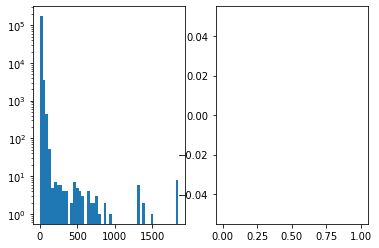

```python
# calculate distance between subsequent points... because now we can add these to see pixel distance covered in an activity
mpd_vals = mouse_pd[['x','y']].values
mouse_dists = [ scipy.spatial.distance.euclidean(mpd_vals[pos_i], mpd_vals[pos_i+1]) for pos_i in range(len(mpd_vals)-1) ]
# so each time point, predicts next distance in mosue movement
mouse_pd['mouse_distances'] = mouse_dists + [mouse_dists[-1]] # pad with last distance

# mouse movements
pylab.subplot(1,2,1)
_ = pylab.hist(mouse_dists, bins=50, log=True)

# take a window over experiment
pylab.subplot(1,2,2)
sample_of_mouse_dists_for_exp = mouse_pd[ (mouse_pd['exp_time'] >= 0) & (mouse_pd['exp_time'] < 3600*2.5) ]['mouse_distances'].values
_ = pylab.hist(sample_of_mouse_dists_for_exp, bins=50) #, log=True)
```

### Calculate difference in times between movements

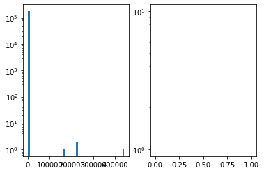

```python
# calculate distance between subsequent points diff of time... because it gives us a feature to look at
mpd_vals = mouse_pd[['exp_time']].values.flatten()

mouse_tdiffs = [ mpd_vals[pos_i+1] - mpd_vals[pos_i] for pos_i in range(len(mpd_vals)-1) ]
# so each time point, predicts next time distance to movement
mouse_pd['mouse_timediffs'] = mouse_tdiffs + [mouse_tdiffs[-1]] # pad with last distance

# only take ones that have a difference
mouse_pd = mouse_pd[ mouse_pd['mouse_timediffs'] > 0]

# mouse time diffs
pylab.subplot(1,2,1)
_ = pylab.hist(mouse_pd['mouse_timediffs'].values, bins=50, log=True)

# take a window over experiment
pylab.subplot(1,2,2)
sample_of_time_diffs_mouse_data_for_exp = mouse_pd[ (mouse_pd['exp_time'] >= 0) & (mouse_pd['exp_time'] < 3600*2.5) ]['mouse_timediffs'].values
_ = pylab.hist(sample_of_time_diffs_mouse_data_for_exp, bins=50, log=True)
```

### Calculate instantaneous velocity

```
(0.0, 30000.0)
```

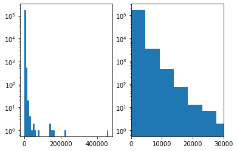

```python
mouse_pd['mouse_velocity'] = mouse_pd['mouse_distances'] * (1/mouse_pd['mouse_timediffs']) # if we moved at this speed for a second, the distance in pixels we would be cover.

# some of these will be NaN - found using
#mouse_pd['mouse_velocity'] = mouse_pd['mouse_distances'] * (1/mouse_pd['mouse_timediffs']) # if we moved at this speed for a second, the distance in pixels we would be cover.
#numpy.where( pandas.isnull(mouse_pd).any(1) )

pylab.subplot(1,2,1)
_ = pylab.hist(mouse_pd['mouse_velocity'].values, bins=50, log=True)

pylab.subplot(1,2,2)
_ = pylab.hist(mouse_pd['mouse_velocity'].values, bins=100, log=True)
pylab.xlim(0,30000)
```

```python
# for euclidean pixel diff distances
data_MOUSE_PIX_DISTS = {}
mpd = mouse_pd

for act_id, exp_time in psycho_py_data[['act_id','exp_time']].values:
    #print(act_id, exp_time)
    data_MOUSE_PIX_DISTS[act_id] = mpd[ (mpd['exp_time'] >= exp_time) & (mpd['exp_time'] < exp_time + DEFAULT_EVENT_TIME)]['mouse_distances'].values

processed_sensor_data['data_MOUSE_PIX_DISTS'] = data_MOUSE_PIX_DISTS

## for time diffs
data_MOUSE_TIMEDIFFS = {}
mpd = mouse_pd

for act_id, exp_time in psycho_py_data[['act_id','exp_time']].values:
    #print(act_id, exp_time)
    data_MOUSE_TIMEDIFFS[act_id] = mpd[ (mpd['exp_time'] >= exp_time) & (mpd['exp_time'] < exp_time + DEFAULT_EVENT_TIME)]['mouse_timediffs'].values

processed_sensor_data['data_MOUSE_TIMEDIFFS'] = data_MOUSE_TIMEDIFFS

## velocities as a feature
data_MOUSE_VELOCITY = {}
mpd = mouse_pd

for act_id, exp_time in psycho_py_data[['act_id','exp_time']].values:
    #print(act_id, exp_time)
    data_MOUSE_VELOCITY[act_id] = mpd[ (mpd['exp_time'] >= exp_time) & (mpd['exp_time'] < exp_time + DEFAULT_EVENT_TIME)]['mouse_velocity'].values

processed_sensor_data['data_MOUSE_VELOCITY'] = data_MOUSE_TIMEDIFFS
```

# EOG

```python
##### load EEG file #####
# by default Ch6 (under eye) is referenced to CMS
# Ch7 was left of eye
# Ch8 was right of eye

EOG_HP_HZ, EOG_LP_HZ = 2,20

eeg_data = mne.io.read_raw_edf(os.path.join(BASE_PATH, EOG_DATA_PATH), preload=True, )

sfreq = eeg_data.info['sfreq']
```

```
Extracting EDF parameters from /home/ham/projects/mart/mart_data/1003/1003.edf...
EDF file detected
EDF annotations detected (consider using raw.find_edf_events() to extract them)
Setting channel info structure...
Creating raw.info structure...
Reading 0 ... 6224999  =      0.000 ... 12449.998 secs...
Used Annotations descriptions: ['Trigger#1190', 'Trigger#1191', 'Trigger#1192', 'Trigger#1220', 'Trigger#1221', 'Trigger#1222', 'Trigger#1030', 'Trigger#1031', 'Trigger#1032', 'Trigger#1300', 'Trigger#1301', 'Trigger#1302', 'Trigger#1250', 'Trigger#1251', 'Trigger#1252', 'Trigger#1385', 'Trigger#138…
```

```python
#for event_id in EVENT_ORDER: print('{} starts at -> Trigger#{}'.format(event_id, event_trigger_ids[event_id] + TRIG_BEGIN) )

event_id_to_annotationID = { event_id:'Trigger#{}'.format(event_trigger_ids[event_id] + TRIG_BEGIN) for event_id in EVENT_ORDER}

print('num annotations: {}'.format( len( eeg_data.annotations.description ) ) )
print('num events: {}'.format( len( mne.find_events(eeg_data) ) ) )

annotation_to_event_index = dict(zip(eeg_data.annotations.description, mne.find_events(eeg_data)))
```

[output not shown]

```python
### we extract event_ids in the same order as they were run from event_order
```

```python
event_ids = []

for event_id in EVENT_ORDER:
    event_ids.append( annotation_to_event_index[event_id_to_annotationID[event_id]] )
```

```python
# if we have event's of diffferent lenghs we need to update this
EPOCH_tmin, EPOCH_tmax = 0, DEFAULT_EVENT_TIME

EOG_RESAMPLING_HZ_TARGET = 100

EOG_BASELINE = None

# we filter the EOG data - eye movement-related EOG will typically be within this range
eeg_data_UD=eeg_data.copy().filter(EOG_HP_HZ, EOG_LP_HZ, \
                                             h_trans_bandwidth='auto',\
                                             #l_trans_bandwidth=.1,\
                                             l_trans_bandwidth='auto',\
                                             filter_length='auto',
                                             phase='zero',
                                             picks = mne.pick_channels(eeg_data.ch_names, include=['Ch6'] )
                                            )

print('eeg_data_UD.shape', eeg_data_UD.get_data().shape)

# let's get up / down movement first
UD_PICK = mne.pick_channels(eeg_data_UD.ch_names, include=['Ch6',] )

# up down epochs
ud_epochs_mne = mne.Epochs(eeg_data_UD, event_ids, tmin=EPOCH_tmin, tmax=EPOCH_tmax, proj=True,
       picks=UD_PICK, preload=True, reject_by_annotation=False, baseline=EOG_BASELINE).resample(EOG_RESAMPLING_HZ_TARGET, npad='auto')

ud_epochs = numpy.squeeze(ud_epochs_mne.get_data())
print('---- ud_epochs.shape', ud_epochs.shape)



# left right epochs
eeg_data_LR = eeg_data.copy().set_eeg_reference(ref_channels=['Ch7']).filter(EOG_HP_HZ, EOG_LP_HZ, \
                                             h_trans_bandwidth='auto',\
                                             #l_trans_bandwidth=.1,\
                                             l_trans_bandwidth='auto',\
                                             filter_length='auto',
                                             phase='zero',
                                             picks = mne.pick_channels(eeg_data.ch_names, include=['Ch8'] )
                                            )


LR_PICK = mne.pick_channels(eeg_data_LR.ch_names, include=['Ch8',] )
#LR_PICK = mne.pick_channels(eeg_data.ch_names, include=['Ch8',] )
lr_epochs_mne = mne.Epochs(eeg_data_LR, event_ids, tmin=EPOCH_tmin, tmax=EPOCH_tmax, proj=True,
       picks=LR_PICK, preload=True, reject_by_annotation=False, baseline=EOG_BASELINE).resample(EOG_RESAMPLING_HZ_TARGET, npad='auto') #.set_eeg_reference(ref_channels=['Ch7'])


lr_epochs = numpy.squeeze(lr_epochs_mne.get_data()[:,0,:]) #<- since one signal ch8 is @ 0


data_EOG_UD_by_activity = dict( zip(EVENT_ORDER, ud_epochs) )
data_EOG_LR_by_activity = dict( zip(EVENT_ORDER, lr_epochs) )

# add code to extract x,y,z from acceleromator

processed_sensor_data['data_EOG_UD_by_activity'] = data_EOG_UD_by_activity
processed_sensor_data['data_EOG_LR_by_activity'] = data_EOG_LR_by_activity
```

```
Filtering a subset of channels. The highpass and lowpass values in the measurement info will not be updated.
Setting up band-pass filter from 2 - 20 Hz
l_trans_bandwidth chosen to be 2.0 Hz
h_trans_bandwidth chosen to be 5.0 Hz
Filter length of 825 samples (1.650 sec) selected
eeg_data_UD.shape (12, 6225000)
63 matching events found
No baseline correction applied
Not setting metadata
0 projection items activated
Loading data for 63 events and 45001 original time points ...
0 bad epochs dropped
---- ud_epochs.shape (63, 9000)
Applying a custom EEG reference.
Filtering a subset of channels. The highpass and lowpass values in the measurement info will not be updated.
Setting up band-pass filter from 2 - 20 Hz
l_trans_bandwidth chosen to be 2.0 Hz
h_trans_bandwidth chosen to be 5.0 Hz
Filter length of 825 samples (1.650 sec) selected
63 matching events found
No baseline correction applied
Not setting metadata
0 projection items activated
Loading data for 63 events and 45001 original time points ...
0 bad epochs dropped
```

### Extract X, Y, Z acceleromator data for head

```python
##### and extracting X,Y,Z

# XYZ_epochs_mne.get_data().shape # (63, 3, 9000)

EPOCH_tmin, EPOCH_tmax = 0, DEFAULT_EVENT_TIME

ACC_HEAD_RESAMPLING_HZ_TARGET = 100

XYZ_PICK = mne.pick_channels(eeg_data.ch_names, include=['X','Y','Z'] )

XYZ_epochs_mne = mne.Epochs(eeg_data, event_ids, tmin=EPOCH_tmin, tmax=EPOCH_tmax, proj=True,
       picks=XYZ_PICK, preload=True, reject_by_annotation=False).resample(ACC_HEAD_RESAMPLING_HZ_TARGET, npad='auto')

#print(XYZ_epochs_mne.ch_names) #['X', 'Y', 'Z']
ACC_SCALER = (1000 * 9.8)
#ACC_SCALER = 1000

# calibration values for acceleromators
xo, yo, zo = [-0.10720707,  0.85672984, -0.11490559]

X_epochs = (numpy.squeeze(XYZ_epochs_mne.get_data()[:,0,:]) / ACC_SCALER) - xo
Y_epochs = (numpy.squeeze(XYZ_epochs_mne.get_data()[:,1,:]) / ACC_SCALER) - yo
Z_epochs = (numpy.squeeze(XYZ_epochs_mne.get_data()[:,2,:]) / ACC_SCALER) - zo

data_HEAD_MAG = ( ( (X_epochs**2) + (Y_epochs**2) + (Z_epochs**2) ) ** .5 ) - ACC_GRAVITY_CONST

data_HEAD_MAG_by_activity = dict( zip(EVENT_ORDER, data_HEAD_MAG) )
data_HEAD_X_by_activity = dict( zip(EVENT_ORDER, X_epochs) )
data_HEAD_Y_by_activity = dict( zip(EVENT_ORDER, Y_epochs) )
data_HEAD_Z_by_activity = dict( zip(EVENT_ORDER, Z_epochs) )

processed_sensor_data['data_HEAD_MAG_by_activity'] = data_HEAD_MAG_by_activity
processed_sensor_data['data_HEAD_X_by_activity'] = data_HEAD_X_by_activity
processed_sensor_data['data_HEAD_Y_by_activity'] = data_HEAD_Y_by_activity
processed_sensor_data['data_HEAD_Z_by_activity'] = data_HEAD_Z_by_activity
```

```
63 matching events found
Applying baseline correction (mode: mean)
Not setting metadata
0 projection items activated
Loading data for 63 events and 45001 original time points ...
0 bad epochs dropped
```

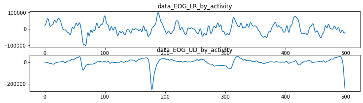

```python
pylab.figure(figsize=(12,3))

si,ei = 2000, 2500
t_act = 'act05_0'

pylab.subplot(2,1,1)
pylab.plot(data_EOG_LR_by_activity[t_act][si:ei])
pylab.title('data_EOG_LR_by_activity')

pylab.subplot(2,1,2)
pylab.plot(data_EOG_UD_by_activity[t_act][si:ei])
pylab.title('data_EOG_UD_by_activity')
```

```python
processed_sensor_data['data_EOG_UD_by_activity'] = data_EOG_UD_by_activity
```

# Processing Heart rate

```python
with open( os.path.join(BASE_PATH, HR_DATA_PATH), 'r' ) as fin:
    heart_rate = fin.readlines()

heart_rate_data = [x.strip() for x in heart_rate]
heart_rate_pandas = pandas.DataFrame([x.strip().split() for x in heart_rate_data if x.strip() != "" and len(x.strip().split()) == 4], columns=['pc_time','rasp_time','dev_id','val'])
heart_rate_pandas['pc_time'] = heart_rate_pandas['pc_time'].astype(float)
heart_rate_pandas['rasp_time'] = heart_rate_pandas['rasp_time'].astype(float)

heart_rate_pandas['exp_time'] = heart_rate_pandas['rasp_time'] - EXP_TIME_AS_ON_PI
```

### if this isin't a straight line there's some major jitter between pi and pc time

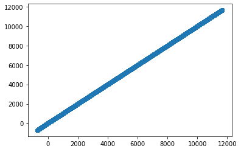

```python
heart_rate_pandas['exp_time_check'] = heart_rate_pandas['pc_time'] - EXP_TIME
pylab.scatter( heart_rate_pandas['exp_time'], heart_rate_pandas['exp_time_check'] )
#heart_rate_pandas = heart_rate_pandas.drop(columns=['exp_time_check'])

# use to find the corrupt lines...
last_v = None
for vi, v in enumerate(heart_rate_pandas['exp_time'].values):
    if last_v == None:
        last_v = v
        continue

    if abs(last_v-v)>1:
        print('diff @ ', vi, last_v - v )
        #break
    last_v = v
```

```
shape is: (1235004,)
```

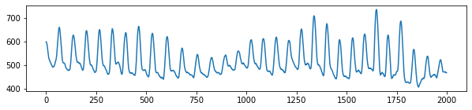

```python
# plot a random section for inspection
i=90088

hr = heart_rate_pandas
d = hr[hr['val']!='None']
x = [float(x) for x in d.iloc[i-1000:i+1000]['val'].values if x!=None ]

pylab.figure(figsize=(10,2))
pylab.plot(x, )

print('shape is:', heart_rate_pandas['val'].shape)
```

```python
# simple algorithm based on autocorrelation to calculate heart rate
# if you want to develop or run your own algorithm e-mail graham.healy@dcu.ie to request the raw data for this!
def calc_window_HR(x, nlags = 100, lowest_rate=40, hr_sps=100, hr_per_unit_time_seconds=60):
    # TODO: add in a HP filter and some other things for data cleaning... but works okay as is.. see plot
    acf_hr = statsmodels.tsa.stattools.acf(x, nlags=nlags )
    hr_ind = numpy.argmax(acf_hr[lowest_rate:])
    hr = hr_per_unit_time_seconds / ( (hr_ind + lowest_rate) / hr_sps )
    return hr

hr_data = heart_rate_pandas['val'].values

hr_win = 400

resample_factor = 100 # i.e. 100 initial SPS Hz, but then turned into 1 SPS Hz but in HR val

hr_data = heart_rate_pandas['val'].values
hr_times_exp_time = heart_rate_pandas['exp_time'].values.tolist()
# hr_times_pi = heart_rate_pandas['rasp_time'].values

# pad both end with hr_win samples
hr_data = numpy.concatenate( [hr_data[:int(hr_win/2)], hr_data[:], hr_data[-int(hr_win/2):]] )
hr_times_exp_time = numpy.concatenate( [ [0] * int(hr_win/2), hr_times_exp_time[:], [0] * int(hr_win/2) ] ) # we'll treat it the same

# resample both at same time for convenience
calced_hr = []
hr_times_exp_time_resampled = []

for i in range(0,len(hr_data)-int(hr_win/2), resample_factor):
    si, ei = i, i+hr_win
    calced_hr.append( calc_window_HR(hr_data[i:i+hr_win])  )
    hr_times_exp_time_resampled.append( hr_times_exp_time[i + int(hr_win/2)] )

calced_hr = calced_hr[int((hr_win/2)/resample_factor): -int((hr_win/2)/resample_factor)] # we chop off only half i.e. it "looks" hr_win/2 back and hr_win/2 forward when caluclating HR
hr_times_exp_time_resampled = hr_times_exp_time_resampled[int((hr_win/2)/resample_factor): -int((hr_win/2)/resample_factor)]

print('calced_hr: seconds of data {}'.format( len(calced_hr)) )
print('hr_times_exp_time_resampled: seconds of data {}'.format( len(hr_times_exp_time_resampled)) )

print('first hr_times_exp_time_resampled occurs at exp_time: {}'.format(hr_times_exp_time_resampled[0]))
```

```
calced_hr: seconds of data 12349
hr_times_exp_time_resampled: seconds of data 12349
first hr_times_exp_time_resampled occurs at exp_time: -716.4581608772278
```

```python
hr_processed_data = pandas.DataFrame( zip(*[hr_times_exp_time_resampled, calced_hr]), columns=['exp_time', 'hr'] )

data_HR_activity = {}
hrpd = hr_processed_data

for act_id, exp_time in psycho_py_data[['act_id','exp_time']].values:
    #print(act_id, exp_time)
    data_HR_activity[act_id] = hrpd[ (hrpd['exp_time'] >= exp_time) & (hrpd['exp_time'] < exp_time + DEFAULT_EVENT_TIME)]['hr'].values

processed_sensor_data['data_HR_activity'] = data_HR_activity
```

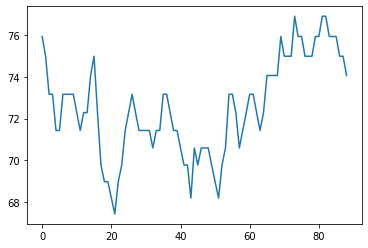

```python
pylab.plot(data_HR_activity['act03_2'])
```

# Processing acceleromator/gyro/mag data

```python
acc_gyro_data = pandas.read_csv( os.path.join(BASE_PATH, ACC_DATA_PATH), dtype={'pc_time':'float64',\
                                                               'rasp_time':'float64',\
                                                               'dev_id':'str',\
                                                               'time_ms':'float64',\
                                                                'accX':'float64',\
                                                               'accY':'float64',\
                                                               'accZ':'float64',\
                                                               'gyroX':'float64',\
                                                               'gyroY':'float64',\
                                                               'gyroZ':'float64',\
                                                               'magX':'float64',\
                                                               'magY':'float64',\
                                                               'magZ':'float64',\
                                                               'qw':'float64',\
                                                               'qx':'float64',\
                                                               'qy':'float64',\
                                                               'qz':'float64' }, sep='\s+|, | ',
                                        names=['pc_time', 'rasp_time', 'dev_id', 'time_ms', 'accX', 'accY', 'accZ', 'gyroX', 'gyroY', 'gyroZ', 'magX', 'magY', 'magZ', 'qw', 'qx', 'qy', 'qz'],
                                       verbose=True)

acc_gyro_data['exp_time'] = acc_gyro_data['rasp_time'] - EXP_TIME_AS_ON_PI

agd = acc_gyro_data
acc_gyro_data['acc_mag'] = (agd['accX'] ** 2 +  agd['accY'] ** 2 +  agd['accZ'] ** 2) ** .5
```

```
acc_gyro_data len before filter 2049548
acc_gyro_data len after filter 2048799
diff is -749
120974
[(120974, 3.068326473236084), (120975, 3.067810535430908), (120976, 3.0577917098999023), (120977, 3.0572614669799805), (120978, 3.0472631454467773), (120979, 3.046828269958496), (120980, 3.03678297996521), (120981, 3.0363306999206543), (120982, 3.0263149738311768), (120983, 3.0256412029266357), (120…
```

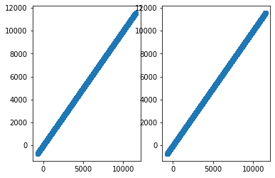

```python
# this should be a straight line too, if not there is a problem
acc_gyro_data['exp_time_check'] = acc_gyro_data['pc_time'] - EXP_TIME

pylab.subplot(1,2,1)
pylab.scatter( acc_gyro_data['exp_time'], acc_gyro_data['exp_time_check'] )
print('acc_gyro_data len before filter', len(acc_gyro_data))
pre_len = len(acc_gyro_data)

# some rows have an error in the second time stamp due to dropped packets, not too many though
acc_gyro_data = acc_gyro_data[ numpy.abs(acc_gyro_data['rasp_time'] - acc_gyro_data['pc_time']) < (PC_PI_DIFF*3) ]
post_len = len(acc_gyro_data)

print('acc_gyro_data len after filter', len(acc_gyro_data))
print('diff is', post_len - pre_len)

pylab.subplot(1,2,2) # let's see with
pylab.scatter( acc_gyro_data['exp_time'], acc_gyro_data['exp_time_check'] )

# there is a corrupt line in 1234, removed from file, use this code to find line number, all ok now
print(numpy.argmax( numpy.abs(acc_gyro_data['exp_time_check'] - acc_gyro_data['exp_time'] ) ))
print(sorted(enumerate(numpy.abs(acc_gyro_data['exp_time_check'] - acc_gyro_data['exp_time'])), reverse=True, key=lambda x: abs(x[1]))[0:20])


acc_gyro_data = acc_gyro_data.drop(columns=['exp_time_check'])
```

### Let's check samples per second across data, histogram should be a straight line unless loosing significant data, or having buffer burps

```
left Acc Gyro Mag samples at 83.9025652560601
right Acc Gyro Mag samples at 84.96035831298413
ACC_GYRO_HZ is 84.4314617845221
```

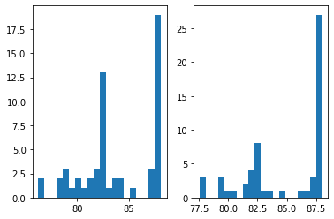

```python
# this will jitter a bit due to buffering but should not be grossly wide
agd = acc_gyro_data

LEFT_DEV = '/dev/ttyACM0'
RIGHT_DEV = '/dev/ttyACM1'

def get_dist(dev, acc_gyro_data=acc_gyro_data, step = 200, psycho_py_data=psycho_py_data):
    samples_per_second = []
    acgd_t = acc_gyro_data[ acc_gyro_data['dev_id']==dev ]
    exp_start = psycho_py_data['exp_time'].values[0]
    exp_end = psycho_py_data['exp_time'].values[-1]

    #for t_ind in numpy.arange( int(acgd_t['exp_time'].values[1]), int(acgd_t['exp_time'].values[-200]), step):
    for t_ind in numpy.arange(exp_start, exp_end, step ):
        win = acgd_t[ (acgd_t['exp_time']>=t_ind) & (acgd_t['exp_time']<t_ind+1) ]
        win_len = len( win )

        win_time_width = win['exp_time'].values[-1] - win['exp_time'].values[0]
        samples_per_second.append( win_len/win_time_width )
    return samples_per_second

left_dist_sps = get_dist(LEFT_DEV,acc_gyro_data=acc_gyro_data)
right_dist_sps = get_dist(RIGHT_DEV,acc_gyro_data=acc_gyro_data)

pylab.subplot(1,2,1)
pylab.hist(left_dist_sps, bins=20)
print('left Acc Gyro Mag samples at {}'.format(numpy.average(left_dist_sps)))

pylab.subplot(1,2,2)
pylab.hist(right_dist_sps, bins=20)
print('right Acc Gyro Mag samples at {}'.format(numpy.average(right_dist_sps)))

ACC_GYRO_HZ = numpy.average( left_dist_sps + right_dist_sps)
print('ACC_GYRO_HZ is', ACC_GYRO_HZ)
```

```python
LEFT_DEV = '/dev/ttyACM0'
RIGHT_DEV = '/dev/ttyACM1'

data_LEFT_ACC_MAG = {}
data_LEFT_ACC_X = {}
data_LEFT_ACC_Y = {}
data_LEFT_ACC_Z = {}

data_RIGHT_ACC_MAG = {}
data_RIGHT_ACC_X = {}
data_RIGHT_ACC_Y = {}
data_RIGHT_ACC_Z = {}

acgd = acc_gyro_data

for act_id, exp_time in psycho_py_data[['act_id','exp_time']].values:
    data_LEFT_ACC_MAG[act_id] = (acgd[(acgd['exp_time'] >= exp_time) & (acgd['exp_time'] < exp_time + DEFAULT_EVENT_TIME)]  [acgd['dev_id']==LEFT_DEV] ['acc_mag'] - ACC_GRAVITY_CONST).values
    data_LEFT_ACC_X[act_id] = (acgd[(acgd['exp_time'] >= exp_time) & (acgd['exp_time'] < exp_time + DEFAULT_EVENT_TIME)]  [acgd['dev_id']==LEFT_DEV] ['accX']).values
    data_LEFT_ACC_Y[act_id] = (acgd[(acgd['exp_time'] >= exp_time) & (acgd['exp_time'] < exp_time + DEFAULT_EVENT_TIME)]  [acgd['dev_id']==LEFT_DEV] ['accY']).values
    data_LEFT_ACC_Z[act_id] = (acgd[(acgd['exp_time'] >= exp_time) & (acgd['exp_time'] < exp_time + DEFAULT_EVENT_TIME)]  [acgd['dev_id']==LEFT_DEV] ['accZ']).values


    data_RIGHT_ACC_MAG[act_id] = (acgd[(acgd['exp_time'] >= exp_time) & (acgd['exp_time'] < exp_time + DEFAULT_EVENT_TIME)]  [acgd['dev_id']==RIGHT_DEV] ['acc_mag']- ACC_GRAVITY_CONST).values
    data_RIGHT_ACC_X[act_id] = (acgd[(acgd['exp_time'] >= exp_time) & (acgd['exp_time'] < exp_time + DEFAULT_EVENT_TIME)]  [acgd['dev_id']==RIGHT_DEV] ['accX']- ACC_GRAVITY_CONST).values
    data_RIGHT_ACC_Y[act_id] = (acgd[(acgd['exp_time'] >= exp_time) & (acgd['exp_time'] < exp_time + DEFAULT_EVENT_TIME)]  [acgd['dev_id']==RIGHT_DEV] ['accY']- ACC_GRAVITY_CONST).values
    data_RIGHT_ACC_Z[act_id] = (acgd[(acgd['exp_time'] >= exp_time) & (acgd['exp_time'] < exp_time + DEFAULT_EVENT_TIME)]  [acgd['dev_id']==RIGHT_DEV] ['accZ']- ACC_GRAVITY_CONST).values


# left
processed_sensor_data['data_LEFT_ACC_MAG'] = data_LEFT_ACC_MAG
processed_sensor_data['data_LEFT_ACC_X'] = data_LEFT_ACC_X
processed_sensor_data['data_LEFT_ACC_Y'] = data_LEFT_ACC_Y
processed_sensor_data['data_LEFT_ACC_Z'] = data_LEFT_ACC_Z

# right
processed_sensor_data['data_RIGHT_ACC_MAG'] = data_RIGHT_ACC_MAG
processed_sensor_data['data_RIGHT_ACC_X'] = data_RIGHT_ACC_X
processed_sensor_data['data_RIGHT_ACC_Y'] = data_RIGHT_ACC_Y
processed_sensor_data['data_RIGHT_ACC_Z'] = data_RIGHT_ACC_Z
```

### Add in ACC fts

```python
# let's create FFT of accelromator magnitudes for a quick inspection... these features seem to offer some discrimination between activities! perhaps task participants will use FFT on acceleromator data
LEFT_DEV = '/dev/ttyACM0'
RIGHT_DEV = '/dev/ttyACM1'

data_LEFT_ACC_MAG_FFT = {}
data_RIGHT_ACC_MAG_FFT = {}

acgd = acc_gyro_data

for act_id, exp_time in psycho_py_data[['act_id','exp_time']].values:
    data_left = (acgd[(acgd['exp_time'] >= exp_time) & (acgd['exp_time'] < exp_time + DEFAULT_EVENT_TIME)]  [acgd['dev_id']==LEFT_DEV] ['acc_mag'] - ACC_GRAVITY_CONST).values
    f, psd = scipy.signal.welch(data_left, fs=ACC_GYRO_HZ, nperseg=ACC_GYRO_HZ*1)
    data_LEFT_ACC_MAG_FFT[act_id] = psd

    data_right = (acgd[(acgd['exp_time'] >= exp_time) & (acgd['exp_time'] < exp_time + DEFAULT_EVENT_TIME)]  [acgd['dev_id']==RIGHT_DEV] ['acc_mag'] - ACC_GRAVITY_CONST).values
    f, psd = scipy.signal.welch(data_left, fs=ACC_GYRO_HZ, nperseg=ACC_GYRO_HZ*1)
    data_RIGHT_ACC_MAG_FFT[act_id] = psd

processed_sensor_data['data_LEFT_ACC_MAG_FFT'] = data_LEFT_ACC_MAG_FFT
processed_sensor_data['data_RIGHT_ACC_MAG_FFT'] = data_RIGHT_ACC_MAG_FFT
```

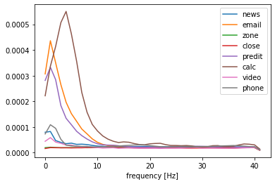

```python
# FFT features may be useful for discerning between activitities. This is something a participating group might want to examine.
acgd = acc_gyro_data

acts = {'act12':'news',\
       'act01':'email',
       'act04':'zone',
       'act16':'close',
       'act03' : 'predit',
        'act05': 'calc',
        'act11': 'video',
        'act14': 'phone'
       }

#email
for act_id_base, label in acts.items():
    accs_t = []
    for i in range(3):
        act_id_t = '{}_{}'.format(act_id_base, i)

        act_id, exp_time = psycho_py_data[psycho_py_data['act_id'] == act_id_t][['act_id','exp_time']].values[0]

        data = (acgd[(acgd['exp_time'] >= exp_time) & (acgd['exp_time'] < exp_time + DEFAULT_EVENT_TIME)]  [acgd['dev_id']==RIGHT_DEV] ['acc_mag'] - ACC_GRAVITY_CONST).values

        f, psd = scipy.signal.welch(data, fs=ACC_GYRO_HZ, nperseg=ACC_GYRO_HZ*1)
        accs_t.append(psd)
        #print(type(f),f.shape)

    f_avg_t = numpy.average(numpy.array(accs_t), axis=0)

    pylab.plot(f_avg_t.flatten()[1:], label=label)


#pylab.ylim([0.5e-3, 1])
pylab.xlabel('frequency [Hz]')
#pylab.ylabel('PSD [V**2/Hz]')
pylab.legend()
pylab.show()
```

# Processing data from autographer

```python
autographer_files = !ls $AUTOGRAPHER_IMAGES_DIR
```

```python
# the alignment image frame
#pylab.imshow( PIL.Image.open(os.path.join(AUTOGRAPHER_IMAGES_DIR, autographer_alignment[SUB_ID][0]+'.JPG')) )

camera_fname_to_time = lambda fname: time.mktime(datetime.datetime.strptime(fname.split('_')[2] + ' ' + fname.split('_')[3].split('.')[0][:-1], '%Y%m%d %H%M%S').timetuple())

time_on_camera = camera_fname_to_time(autographer_alignment[SUB_ID][0])
time_on_pc_for_same_frame_on_autographer = autographer_alignment[SUB_ID][1]

#EXP_TIME = psycho_py_data['pc_time'][0]

PC_AUTOGRAPHER_TIME_DIFF = time_on_pc_for_same_frame_on_autographer - time_on_camera

EXP_TIME_AS_ON_AUTHOGRAPHER = EXP_TIME - PC_AUTOGRAPHER_TIME_DIFF
```

```
B00004522_21I6TX_20180717_055548E.JPG
```

[figure not shown]

```python
autographer_files = autographer_files
imgs_PIL = [ PIL.Image.open(os.path.join(AUTOGRAPHER_IMAGES_DIR, autographer_files[i])) for i in range(len(autographer_files)) ]

# view file_ind image
file_ind = 60
print(autographer_files[file_ind])
pylab.imshow(imgs_PIL[file_ind])
```

## Extract predictions

- As an example to support baseline system. Task participants will likely create/select better performing models.

```python
# Downloading: "https://download.pytorch.org/models/alexnet-owt-4df8aa71.pth" to /home/ham/.cache/torch/checkpoints/alexnet-owt-4df8aa71.pth
# Downloading: "https://download.pytorch.org/models/resnet101-5d3b4d8f.pth" to /home/ham/.cache/torch/checkpoints/resnet101-5d3b4d8f.pth

resnet101 = torchvision.models.resnet101(pretrained=True).cuda()

transform = torchvision.transforms.Compose([            #[1]
 torchvision.transforms.Resize(256),                    #[2]
# torchvision.transforms.CenterCrop(224),                #[3]
 torchvision.transforms.ToTensor(),                     #[4]
 torchvision.transforms.Normalize(                      #[5]
 mean=[0.485, 0.456, 0.406],                #[6]
 std=[0.229, 0.224, 0.225]                  #[7]
 )])

resnet101.cuda()
resnet101.eval()

imgs_transformed = []

for img in imgs_PIL:
    #print(img)
    imgs_transformed += [ transform(img) ]

nn_score = lambda x: torch.nn.functional.softmax(x, dim=1) * 100

image_predictions = [ nn_score(resnet101(torch.unsqueeze(trans_img, 0).cuda())).tolist()[0] for trans_img in imgs_transformed]
```

### put into pandas frame

```python
pd_data_t = [ [autographer_file,*preds, img_PIL] for autographer_file,preds,img_PIL in zip(autographer_files, image_predictions, imgs_PIL) ]
autographer_viz_data = pandas.DataFrame(pd_data_t,columns=['fname',*IMAGE_NET_CLASSES,'im_data'])

autographer_viz_data['fname_times'] = autographer_viz_data['fname'].apply(camera_fname_to_time)
autographer_viz_data['exp_time'] = autographer_viz_data['fname_times'] - EXP_TIME_AS_ON_AUTHOGRAPHER
```

```python
data_AUTOGRAPHER_RESNET = {}

avd = autographer_viz_data

for act_id, exp_time in psycho_py_data[['act_id','exp_time']].values:
    data_AUTOGRAPHER_RESNET[act_id] = avd[(avd['exp_time'] >= exp_time) & (avd['exp_time'] < exp_time + DEFAULT_EVENT_TIME)]

processed_sensor_data['data_AUTOGRAPHER_RESNET_mean'] = { act_id:data_AUTOGRAPHER_RESNET[act_id].drop( columns=['fname','exp_time','fname_times', 'im_data'] ).mean() for act_id in data_AUTOGRAPHER_RESNET.keys() }
processed_sensor_data['data_AUTOGRAPHER_RESNET_min'] = { act_id:data_AUTOGRAPHER_RESNET[act_id].drop( columns=['fname','exp_time','fname_times', 'im_data'] ).min() for act_id in data_AUTOGRAPHER_RESNET.keys() }
processed_sensor_data['data_AUTOGRAPHER_RESNET_max'] = { act_id:data_AUTOGRAPHER_RESNET[act_id].drop( columns=['fname','exp_time','fname_times', 'im_data'] ).max() for act_id in data_AUTOGRAPHER_RESNET.keys() }

#processed_sensor_data['data_AUTOGRAPHER_RESNET'] = data_AUTOGRAPHER_RESNET
```

## visual check that images align with activities

- look at each of first, middle and last

```python
if SHOW_DATA_DIST_PLOTS:
    nrows = len(events_text)
    ncols = 3 # number of repeat activities

    #tweak to align to image as specific offset - i.e. middle, first last, etcc
    im_ind_to_sample = lambda x: int(len(x)/2)
    im_ind_to_sample = lambda x: 1

    pylab.figure(figsize=(30,90))

    for ev_i, (event_id, event_text) in enumerate(events_text.items()):
        for ind in range(ncols):
            event_ind = '{}_{}'.format(event_id, ind)
            fname, im_data = zip(*data_AUTOGRAPHER_RESNET[event_ind][['fname','im_data']].values)

            title = '{}'.format(event_text)

            pylab.subplot(nrows, ncols, (ev_i*ncols)+1+ind)
            pylab.title(title)
            pylab.imshow( im_data[im_ind_to_sample(im_data)]  )

            pylab.tight_layout()
```

# Visualize data distplots

```python
if SHOW_DATA_DIST_PLOTS:
    ncols = 5
    nrows = 21
    pylab.figure(figsize=(25,40))

    for j in range(3):
        for i in range(21):
            act_id = j # which set of acti vities to plot
            act = "act{:02d}_{}".format(i, act_id)

            ev_text = events_text[act.split('_')[0]]

            pylab.subplot(nrows,ncols,(i*ncols)+1)
            #data_source1 = ['data_LEFT_ACC_MAG']
            seaborn.distplot(processed_sensor_data['data_EOG_UD_by_activity'][act], bins=None, label=str(j))
            pylab.title(events_text[act.split('_')[0]])
            pylab.xlim((-500000,500000))

            pylab.subplot(nrows,ncols,(i*ncols)+2)
            seaborn.distplot(processed_sensor_data['data_EOG_LR_by_activity'][act], bins=None, label=str(j))
            pylab.title('data_EOG_LR_by_activity')
            pylab.xlim((-500000,500000))

            pylab.subplot(nrows,ncols,(i*ncols)+3)
            #seaborn.distplot(processed_sensor_data['data_MOUSE_VELOCITY'][act], bins=None, label=str(j))
            pylab.hist(processed_sensor_data['data_MOUSE_VELOCITY'][act], bins=None, log=True )
            pylab.title(str(j))
            pylab.title('data_MOUSE_VELOCITY')

            pylab.subplot(nrows,ncols,(i*ncols)+4)
            #seaborn.distplot(processed_sensor_data['data_MOUSE_VELOCITY'][act], bins=None, label=str(j))
            pylab.hist(processed_sensor_data['data_MOUSE_PIX_DISTS'][act], bins=None, log=True )
            pylab.title(str(j))
            pylab.title('data_MOUSE_VELOCITY')

            pylab.subplot(nrows,ncols,(i*ncols)+5)
            #seaborn.distplot(processed_sensor_data['data_MOUSE_VELOCITY'][act], bins=None, label=str(j))
            pylab.hist(processed_sensor_data['data_MOUSE_TIMEDIFFS'][act], bins=None, log=True )
            pylab.title(str(j))
            pylab.title('data_MOUSE_VELOCITY')

    pylab.tight_layout()
```

```python
if SHOW_DATA_DIST_PLOTS:
    ncols = 8
    nrows = 21
    pylab.figure(figsize=(25,40))

    for j in range(3):
        for i in range(21):
            act_id = j # which set of acti vities to plot
            act = "act{:02d}_{}".format(i, act_id)

            ev_text = events_text[act.split('_')[0]]

            pylab.subplot(nrows,ncols,(i*ncols)+1)
            #data_source1 = ['data_LEFT_ACC_MAG']
            seaborn.distplot(processed_sensor_data['data_EOG_UD_by_activity'][act], bins=None, label=str(j))
            pylab.title(events_text[act.split('_')[0]])
            pylab.xlim((-500000,500000))

            pylab.subplot(nrows,ncols,(i*ncols)+2)
            seaborn.distplot(processed_sensor_data['data_EOG_LR_by_activity'][act], bins=None, label=str(j))
            pylab.title('data_EOG_LR_by_activity')
            pylab.xlim((-500000,500000))

            pylab.subplot(nrows,ncols,(i*ncols)+3)
            seaborn.distplot(processed_sensor_data['data_HR_activity'][act], bins=None, label=str(j))
            pylab.title('data_HR_activity')
            pylab.xlim((40, 120))

            pylab.subplot(nrows,ncols,(i*ncols)+4)
            seaborn.distplot(processed_sensor_data['data_LEFT_ACC_MAG'][act], bins=None, label=str(j))
            pylab.title('data_LEFT_ACC_MAG')
            pylab.xlim((-1, 1))

            pylab.subplot(nrows,ncols,(i*ncols)+5)
            seaborn.distplot(processed_sensor_data['data_RIGHT_ACC_MAG'][act], bins=None, label=str(j))
            pylab.title('data_RIGHT_ACC_MAG')
            pylab.xlim((-1, 1))

            pylab.subplot(nrows,ncols,(i*ncols)+6)
            seaborn.distplot(processed_sensor_data['data_HEAD_MAG_by_activity'][act], bins=None, label=str(j))
            pylab.title('data_HEAD_MAG_by_activity')
            pylab.xlim((-2, 2))

            pylab.subplot(nrows,ncols,(i*ncols)+7)
            #seaborn.distplot(processed_sensor_data['data_MOUSE_VELOCITY'][act], bins=None, label=str(j))
            pylab.hist(processed_sensor_data['data_MOUSE_VELOCITY'][act], bins=None, log=True )
            pylab.title(str(j))
            pylab.title('data_MOUSE_VELOCITY')

            pylab.subplot(nrows,ncols,(i*ncols)+8)
            #seaborn.distplot(processed_sensor_data['data_MOUSE_VELOCITY'][act], bins=None, label=str(j))
            pylab.plot(processed_sensor_data['data_RIGHT_ACC_MAG_FFT'][act]) #, bins=None, log=True )
            pylab.title(str(j))
            pylab.ylim((0,.015))
            pylab.title('data_RIGHT_ACC_MAG_FFT')

    pylab.tight_layout()
```

```python
if SHOW_DATA_DIST_PLOTS:
    ncols = 12
    nrows = 21
    pylab.figure(figsize=(35,40))
    bw = 20
    dist_bins = 15
    x_lim_lower = -1.5
    x_lim_upper = 1.5

    pylab.xlim((x_lim_lower, x_lim_upper))

    kde_kws = {'bw':bw, 'cumulative':True}

    for j in range(3):
        for i in range(21):
            act_id = j # which set of acti vities to plot
            act = "act{:02d}_{}".format(i, act_id)

            ev_text = events_text[act.split('_')[0]]

            # left hand acceleromator
            pylab.subplot(nrows,ncols,(i*ncols)+1)
            seaborn.distplot(processed_sensor_data['data_LEFT_ACC_MAG'][act], bins=dist_bins, label=str(j), kde_kws = kde_kws)
            #pylab.title('data_LEFT_ACC_MAG')
            pylab.title(events_text[act.split('_')[0]])
            pylab.xlim((x_lim_lower, x_lim_upper))

            pylab.subplot(nrows,ncols,(i*ncols)+2)
            seaborn.distplot(processed_sensor_data['data_LEFT_ACC_X'][act], bins=dist_bins, label=str(j), kde_kws = kde_kws)
            pylab.title('data_LEFT_ACC_X')
            pylab.xlim((x_lim_lower, x_lim_upper))

            pylab.subplot(nrows,ncols,(i*ncols)+3)
            seaborn.distplot(processed_sensor_data['data_LEFT_ACC_Y'][act], bins=dist_bins, label=str(j), kde_kws = kde_kws)
            pylab.title('data_LEFT_ACC_Y')
            pylab.xlim((x_lim_lower, x_lim_upper))

            pylab.subplot(nrows,ncols,(i*ncols)+4)
            seaborn.distplot(processed_sensor_data['data_LEFT_ACC_Z'][act], bins=dist_bins, label=str(j), kde_kws = kde_kws)
            pylab.title('data_LEFT_ACC_Z')
            pylab.xlim((x_lim_lower, x_lim_upper))

            # right hand acceleromator
            pylab.subplot(nrows,ncols,(i*ncols)+5)
            seaborn.distplot(processed_sensor_data['data_RIGHT_ACC_MAG'][act], bins=dist_bins, label=str(j), kde_kws = kde_kws)
            pylab.title('data_RIGHT_ACC_MAG')
            pylab.xlim((x_lim_lower, x_lim_upper))

            pylab.subplot(nrows,ncols,(i*ncols)+6)
            seaborn.distplot(processed_sensor_data['data_RIGHT_ACC_X'][act], bins=dist_bins, label=str(j), kde_kws = kde_kws)
            pylab.title('data_RIGHT_ACC_X')
            pylab.xlim((x_lim_lower, x_lim_upper))

            pylab.subplot(nrows,ncols,(i*ncols)+7)
            seaborn.distplot(processed_sensor_data['data_RIGHT_ACC_Y'][act], bins=dist_bins, label=str(j), kde_kws = kde_kws)
            pylab.title('data_RIGHT_ACC_Y')
            pylab.xlim((x_lim_lower, x_lim_upper))

            pylab.subplot(nrows,ncols,(i*ncols)+8)
            seaborn.distplot(processed_sensor_data['data_RIGHT_ACC_Z'][act], bins=dist_bins, label=str(j), kde_kws = kde_kws)
            pylab.title('data_RIGHT_ACC_Z')
            pylab.xlim((x_lim_lower, x_lim_upper))

            # head
            pylab.subplot(nrows,ncols,(i*ncols)+9)
            seaborn.distplot(processed_sensor_data['data_HEAD_MAG_by_activity'][act], bins=dist_bins, label=str(j), kde_kws = kde_kws)
            pylab.title('data_HEAD_MAG_by_activity')
            pylab.xlim((x_lim_lower, x_lim_upper))

            pylab.subplot(nrows,ncols,(i*ncols)+10)
            seaborn.distplot(processed_sensor_data['data_HEAD_X_by_activity'][act], bins=dist_bins, label=str(j), kde_kws = kde_kws)
            pylab.title('data_HEAD_X_by_activity')
            pylab.xlim((x_lim_lower, x_lim_upper))

            pylab.subplot(nrows,ncols,(i*ncols)+11)
            seaborn.distplot(processed_sensor_data['data_HEAD_Y_by_activity'][act], bins=dist_bins, label=str(j), kde_kws = kde_kws)
            pylab.title('data_HEAD_Y_by_activity')
            pylab.xlim((x_lim_lower, x_lim_upper))

            pylab.subplot(nrows,ncols,(i*ncols)+12)
            seaborn.distplot(processed_sensor_data['data_HEAD_Z_by_activity'][act], bins=dist_bins, label=str(j))
            pylab.title('data_HEAD_Z_by_activity')
            pylab.xlim((x_lim_lower, x_lim_upper))

    pylab.tight_layout()
```

# Formats text files of raw/processed-raw data:

- Let's output the data to DATA_OUTPUT_DIR as txt files and pandas dataframes for each participant id
- select list of outputs in output_sensor_types = [] (default is all)
- data types can be extended!

```python
# part of selecting which 2 are training and which is testing
RANDOMIZATION_KEY_FOR_SELECTION_OF_TRIALS_SEED = REMOVED!! # hide this before notebook release!
RANDOMIZATION_KEY_FOR_SELECTION_OF_TRIALS = RANDOMIZATION_KEY_FOR_SELECTION_OF_TRIALS_SEED + SUB_ID
```

## This is a list of the sensor streams we output and process

```python
output_sensor_types=[
'data_HR_activity',

 'data_LEFT_ACC_MAG', 'data_LEFT_ACC_X', 'data_LEFT_ACC_Y', 'data_LEFT_ACC_Z',
 'data_RIGHT_ACC_MAG', 'data_RIGHT_ACC_X', 'data_RIGHT_ACC_Y', 'data_RIGHT_ACC_Z',

 'data_HEAD_MAG_by_activity','data_HEAD_X_by_activity','data_HEAD_Y_by_activity','data_HEAD_Z_by_activity',

 'data_MOUSE_PIX_DISTS',
 'data_MOUSE_TIMEDIFFS',
 'data_MOUSE_VELOCITY',

 'data_EOG_UD_by_activity',
 'data_EOG_LR_by_activity',

 #'data_LEFT_ACC_MAG_FFT',
 #'data_RIGHT_ACC_MAG_FFT',

 'data_AUTOGRAPHER_RESNET_mean',
 'data_AUTOGRAPHER_RESNET_min',
 'data_AUTOGRAPHER_RESNET_max',
]
```

## These are the features we will extract and put into a pandas dataframe (and how)

```python
def ft_set_1(a, sensor_type=''):
    fts = collections.OrderedDict()
    if len(a)!=0:
        fts[sensor_type + '_median'] = numpy.median(a)
        fts[sensor_type + '_min'] = numpy.min(a)
        fts[sensor_type + '_max'] = numpy.max(a)
        fts[sensor_type + '_average'] = numpy.average(a)
        fts[sensor_type + '_std'] = numpy.std(a)
        #fts['mode'] = scipy.stats.mode(a)
        fts[sensor_type + '_len'] = len(a)
    else:
        fts[sensor_type + '_median'] = None
        fts[sensor_type + '_min'] = None
        fts[sensor_type + '_max'] = None
        fts[sensor_type + '_average'] = None
        fts[sensor_type + '_std'] = None
        #fts['mode'] = None
        fts[sensor_type + '_len'] = 0

    return fts

# don't process, push through IMAGE_NET_CLASSES labels
def ft_fallthrough_resnet(a, sensor_type=''):
    fts = collections.OrderedDict()

    for ft_name, ft_val in zip([sensor_type + '_' + name for name in IMAGE_NET_CLASSES], a):
        fts[ft_name] = ft_val

    return fts

pandas_feature_set_for_release = \
{'data_EOG_UD_by_activity' : ft_set_1,
'data_EOG_LR_by_activity': ft_set_1,

'data_RIGHT_ACC_MAG_FFT': ft_set_1,

'data_LEFT_ACC_MAG': ft_set_1,
'data_LEFT_ACC_X': ft_set_1,
'data_LEFT_ACC_Y': ft_set_1,
'data_LEFT_ACC_Z': ft_set_1,

'data_RIGHT_ACC_MAG': ft_set_1,
'data_RIGHT_ACC_X': ft_set_1,
'data_RIGHT_ACC_Y': ft_set_1,
'data_RIGHT_ACC_Z': ft_set_1,

'data_HEAD_MAG_by_activity': ft_set_1,
'data_HEAD_X_by_activity': ft_set_1,
'data_HEAD_Y_by_activity': ft_set_1,
'data_HEAD_Z_by_activity': ft_set_1,

'data_HR_activity': ft_set_1,

'data_mouse_dist': ft_set_1,
'data_MOUSE_TIMEDIFFS': ft_set_1,
'data_MOUSE_PIX_DISTS': ft_set_1,
'data_MOUSE_VELOCITY': ft_set_1,
'data_LEFT_ACC_MAG_FFT': ft_set_1,

'data_AUTOGRAPHER_RESNET_mean': ft_fallthrough_resnet,
'data_AUTOGRAPHER_RESNET_max': ft_fallthrough_resnet,
'data_AUTOGRAPHER_RESNET_min': ft_fallthrough_resnet, }


def stats_for_data(vals, sensor_type, feature_set_for_release):

    ft_func = feature_set_for_release[sensor_type]
    fts = ft_func(vals, sensor_type=sensor_type)
    fts_names, fts_vals = zip(*fts.items())

    return fts_vals, [ft_name for ft_name in fts_names]
```

## make folder structure

```python
mkdir(DATA_OUTPUT_DIR)
mkdir(DATA_OUTPUT_DIR_TXT)
mkdir(DATA_OUTPUT_DIR_PANDAS)

mkdir(os.path.join(DATA_OUTPUT_DIR_SCREENSHOTS, 'trainA'))
mkdir(os.path.join(DATA_OUTPUT_DIR_SCREENSHOTS, 'trainB'))
mkdir(os.path.join(DATA_OUTPUT_DIR_SCREENSHOTS, 'test'))

mkdir(os.path.join(DATA_OUTPUT_DIR_AUTOGRAPHER, 'trainA'))
mkdir(os.path.join(DATA_OUTPUT_DIR_AUTOGRAPHER, 'trainB'))
mkdir(os.path.join(DATA_OUTPUT_DIR_AUTOGRAPHER, 'test'))

mkdir(DATA_OUTPUT_DIR_SECRETS)
```

## Write data to text file and pandas dataframe, and copy images for authographer and screen at the same time

```python
def output_txt_data_to_file(data, fname):
    with open(os.path.join(DATA_OUTPUT_DIR_TXT,fname), 'w') as fout:
        for d in data:
            fout.write("{:.10f}\n".format(d))



# create secret pairing of test events and their key
ev_types = [event_type for ev_i, event_type in enumerate(sorted(list(set([x.split('_')[0] for x in EVENT_ORDER])-set(['act00'])))) ] # this is only used for creating secret_pairing.. act01->act20
#print(zip(ev_types, ev_types2))
#shs
ev_ids_rand = list(range(len(ev_types)))
random.seed(RANDOMIZATION_KEY_FOR_SELECTION_OF_TRIALS + SUB_ID)
random.shuffle(ev_ids_rand)
secret_pairing = dict(zip(ev_types, ev_ids_rand))

with open(os.path.join(DATA_OUTPUT_DIR_SECRETS, 'secret_{}.txt'.format(SUB_ID)), 'w') as fout:
    fout.write('seed: {}\n'.format( RANDOMIZATION_KEY_FOR_SELECTION_OF_TRIALS) )
    fout.write('SUB_ID: {}\n'.format( SUB_ID) )

    for ev_type, ev_id in secret_pairing.items():
        fout.write("{} {}\n".format(ev_type, ev_id))

    fts_vals_events_train0, fts_vals_events_train1, fts_vals_events_test = [], [], []

    # for each event type select one (i.e. act18_1 as the test set and the other two as training)
    for event_type in sorted(list(set([x.split('_')[0] for x in EVENT_ORDER])-set(['act00']))):
        ind_of_test = random.randint(0,2) # random int to select test
        inds_of_trains = sorted(list(set([0,1,2,]) - set([ind_of_test])))
        fout.write("{} test={} train0={} train1={}\n".format(event_type, ind_of_test, inds_of_trains[0], inds_of_trains[1]))

        # copy image files related to each event to their own subdirectory
        for fname_i, fname in enumerate(data_AUTOGRAPHER_RESNET["{}_{}".format(event_type, inds_of_trains[0])]['fname'].values):
            shutil.copyfile( os.path.join(AUTOGRAPHER_IMAGES_DIR, fname), os.path.join(DATA_OUTPUT_DIR_AUTOGRAPHER, 'trainA', '{}_trainA_{}_{}.jpg'.format(SUB_ID, event_type,fname_i )) )
        for fname_i, fname in enumerate(data_AUTOGRAPHER_RESNET["{}_{}".format(event_type, inds_of_trains[1])]['fname'].values):
            shutil.copyfile( os.path.join(AUTOGRAPHER_IMAGES_DIR, fname), os.path.join(DATA_OUTPUT_DIR_AUTOGRAPHER, 'trainB', '{}_trainB_{}_{}.jpg'.format(SUB_ID, event_type,fname_i )) )
        for fname_i, fname in enumerate(data_AUTOGRAPHER_RESNET["{}_{}".format(event_type, ind_of_test)]['fname'].values):
            shutil.copyfile( os.path.join(AUTOGRAPHER_IMAGES_DIR, fname), os.path.join(DATA_OUTPUT_DIR_AUTOGRAPHER, 'test', '{}_pred{}_{}.jpg'.format(SUB_ID, secret_pairing[event_type],fname_i )) )

        # copy image files related to each event to their own subdirectory
        for fname_i, fname in enumerate(data_loggerman_screen["{}_{}".format(event_type, inds_of_trains[0])]['fname'].values):
            shutil.copyfile( os.path.join(LOGGERMAN_IMAGES_DIR, fname), os.path.join(DATA_OUTPUT_DIR_SCREENSHOTS, 'trainA', '{}_trainA_{}_{}.jpg'.format(SUB_ID, event_type,fname_i )) )
        for fname_i, fname in enumerate(data_loggerman_screen["{}_{}".format(event_type, inds_of_trains[1])]['fname'].values):
            shutil.copyfile( os.path.join(LOGGERMAN_IMAGES_DIR, fname), os.path.join(DATA_OUTPUT_DIR_SCREENSHOTS, 'trainB', '{}_trainB_{}_{}.jpg'.format(SUB_ID, event_type,fname_i )) )
        for fname_i, fname in enumerate(data_loggerman_screen["{}_{}".format(event_type, ind_of_test)]['fname'].values):
            shutil.copyfile( os.path.join(LOGGERMAN_IMAGES_DIR, fname), os.path.join(DATA_OUTPUT_DIR_SCREENSHOTS, 'test', '{}_pred{}_{}.jpg'.format(SUB_ID, secret_pairing[event_type],fname_i )) )

        sensor_fts_train0, sensor_fts_train1, sensor_fts_test = [], [], []
        sensor_fts_names_train0, sensor_fts_names_train1, sensor_fts_names_test = [], [], []

        # output sensor data to txt file, and store in array to be packaged into pandas dataframe
        for sensor_type in output_sensor_types:
            # train 0
            #print(sensor_type)
            d_train0 = processed_sensor_data[sensor_type]["{}_{}".format(event_type, inds_of_trains[0])]
            output_txt_data_to_file(d_train0, "train_{}_{}_{}_{}.txt".format(SUB_ID, sensor_type, event_type, 'A') )
            fout.write( "writing train0 {} using {}\n".format("train_{}_{}_{}_{}.txt".format(SUB_ID, sensor_type, event_type, 'A'), "{}_{}".format(event_type, inds_of_trains[0])) )
            sensor_ft_vals, sensor_ft_names = stats_for_data(d_train0, sensor_type, pandas_feature_set_for_release)
            sensor_fts_train0 += sensor_ft_vals
            sensor_fts_names_train0 += sensor_ft_names

            # train 1
            d_train1 = processed_sensor_data[sensor_type]["{}_{}".format(event_type, inds_of_trains[1])]
            output_txt_data_to_file(d_train1, "train_{}_{}_{}_{}.txt".format(SUB_ID, sensor_type, event_type, 'B') )
            fout.write( "writing train1 {} using {}\n".format("train_{}_{}_{}_{}.txt".format(SUB_ID, sensor_type, event_type, 'B'), "{}_{}".format(event_type, inds_of_trains[1])) )
            sensor_ft_vals, sensor_ft_names = stats_for_data(d_train1, sensor_type, pandas_feature_set_for_release)
            sensor_fts_train1 += sensor_ft_vals
            sensor_fts_names_train1 += sensor_ft_names

            #test 1
            # don't include event_type here, that's to be predicted later. use another ID.
            d_test = processed_sensor_data[sensor_type]["{}_{}".format(event_type, ind_of_test)]
            output_txt_data_to_file(d_test, "test_{}_{}_pred{}.txt".format(SUB_ID, sensor_type, secret_pairing[event_type] ))
            fout.write( "writing {} using {}\n".format("test_{}_{}_pred{}.txt".format(SUB_ID, sensor_type, secret_pairing[event_type] ), "{}_{}".format(event_type, ind_of_test) ) )
            sensor_ft_vals, sensor_ft_names = stats_for_data(d_test, sensor_type, pandas_feature_set_for_release)
            sensor_fts_test += sensor_ft_vals
            sensor_fts_names_test += sensor_ft_names

        # collect a row for each event with all sensors readings combined
        fts_vals_events_train0.append(["{}".format(SUB_ID), event_type, 'trainA'] + sensor_fts_train0)
        fts_vals_events_train1.append(["{}".format(SUB_ID), event_type, 'trainB'] + sensor_fts_train1)
        fts_vals_events_test.append(["{}".format(SUB_ID), "pred{}".format(secret_pairing[event_type]), 'test'] + sensor_fts_test)

# randomize the row order here as activity ids could be figured out by ordered added to pandas
random.seed(RANDOMIZATION_KEY_FOR_SELECTION_OF_TRIALS)
random.shuffle(fts_vals_events_test)

PANDAS_DATA_ALL_TRAIN0 = pandas.DataFrame(data = fts_vals_events_train0, columns=['sub_id', 'event_id', 'source'] + sensor_fts_names_train0)
PANDAS_DATA_ALL_TRAIN1 = pandas.DataFrame(data = fts_vals_events_train1, columns=['sub_id', 'event_id', 'source'] + sensor_fts_names_train1)
PANDAS_DATA_ALL_TEST = pandas.DataFrame(data = fts_vals_events_test, columns=['sub_id', 'event_id', 'source'] + sensor_fts_names_test)

# write out pandas dataframes to csv
PANDAS_DATA_ALL_TEST.to_csv( os.path.join(DATA_OUTPUT_DIR_PANDAS, '{}_{}.csv'.format(SUB_ID, 'test')) )
PANDAS_DATA_ALL_TRAIN0.to_csv( os.path.join(DATA_OUTPUT_DIR_PANDAS, '{}_{}.csv'.format(SUB_ID, 'trainA')) )
PANDAS_DATA_ALL_TRAIN1.to_csv( os.path.join(DATA_OUTPUT_DIR_PANDAS, '{}_{}.csv'.format(SUB_ID, 'trainB')) )
```

```python
SUB_ID
```

[output not shown]

# END of processing/output script